# Forecasting with Two-way ANOVA

Anita Owens

Question: Do coupons and advertising affects peanut butter sales?

## 1. Set up environment

```r
# Install pacman if needed
if (!require("pacman")) install.packages("pacman")
# load packages
pacman::p_load(pacman,
  tidyverse, openxlsx, ggpubr)
```

## 2. Load data

```r
#Dataset is in datasets subfolder
(peanutbutter <- read.xlsx("datasets/Coupondata.xlsx"))
```

|  | Advertising | COUPON | No.coupon |
| --- | --- | --- | --- |
| 1 | No ad | 95 | 60 |
| 2 | No ad | 90 | 75 |
| 3 | No ad | 85 | 79 |
| 4 | ad | 170 | 130 |
| 5 | ad | 150 | 140 |
| 6 | ad | 190 | 170 |

```r
#Lowercase column names
(peanutbutter<- rename_with(peanutbutter, tolower))
```

|  | advertising | coupon | no.coupon |
| --- | --- | --- | --- |
| 1 | No ad | 95 | 60 |
| 2 | No ad | 90 | 75 |
| 3 | No ad | 85 | 79 |
| 4 | ad | 170 | 130 |
| 5 | ad | 150 | 140 |
| 6 | ad | 190 | 170 |

```r
(peanutbutter_long <- peanutbutter %>%
  pivot_longer(!advertising, names_to = "coupon", values_to = "sales"))
```

| advertising | coupon | sales |
| --- | --- | --- |
| No ad | coupon | 95 |
| No ad | no.coupon | 60 |
| No ad | coupon | 90 |
| No ad | no.coupon | 75 |
| No ad | coupon | 85 |
| No ad | no.coupon | 79 |
| ad | coupon | 170 |
| ad | no.coupon | 130 |
| ad | coupon | 150 |
| ad | no.coupon | 140 |

[output cut: 2 more lines]

## 3. Data Visualization

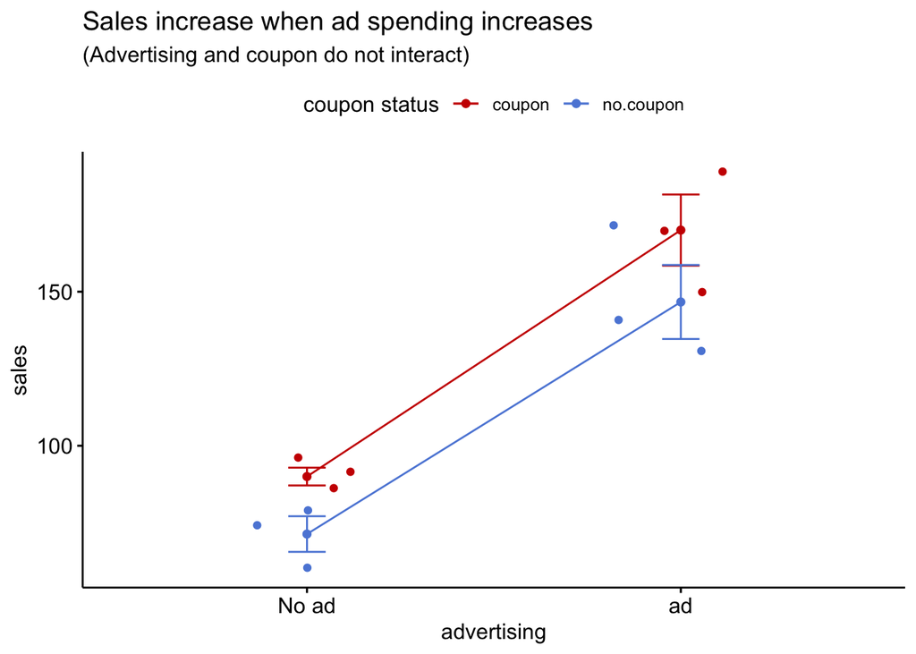

```r
#Plot using ggpubr
ggline(peanutbutter_long, x = "advertising", y = "sales",
       add = c("mean_se", "jitter"),
       color = "coupon", palette = "startrek",
       title = "Sales increase when ad spending increases",
       subtitle = "(Advertising and coupon do not interact) ",
       legend.title = "coupon status"
       )
```

## 4. Two-way ANOVA

```r
two_way_aov <- aov(sales ~ advertising*coupon, data = peanutbutter_long)

#The anova table
summary(two_way_aov)
```

```
##                    Df Sum Sq Mean Sq F value  Pr(>F)
## advertising         1  18096   18096  75.506 2.4e-05 ***
## coupon              1   1323    1323   5.520  0.0467 *
## advertising:coupon  1     16      16   0.068  0.8006
## Residuals           8   1917     240
## ---
## Signif. codes:  0 '***' 0.001 '**' 0.01 '*' 0.05 '.' 0.1 ' ' 1
```

Since the p-values for the main effects advertising and then coupon are small and the interaction (advertising*coupon) is very large. Advertising and coupon factors (separately) increases sales.

## 5. AOV Model Diagnostics

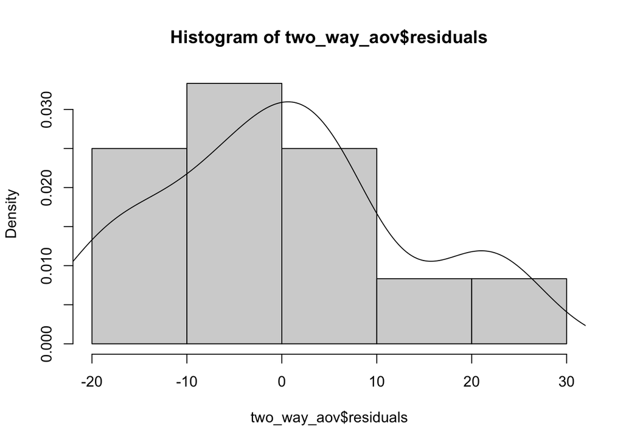

```r
#Diagnostic plots
#plot(two_way_aov)

hist(two_way_aov$residuals, prob = TRUE)
lines(density(two_way_aov$residuals))
```

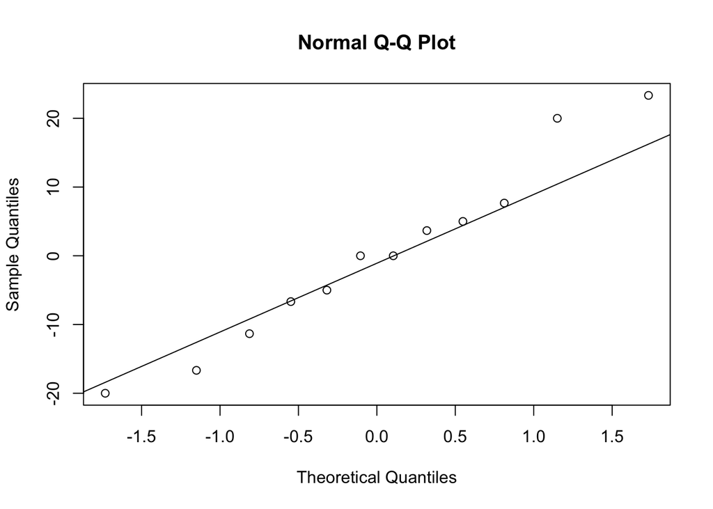

```r
qqnorm(two_way_aov$residuals)
qqline(two_way_aov$residuals)
```

## 6. Forecast

```r
#What we can expect in sales when there is advertising vs. no advertising
peanutbutter_long %>%
  group_by(advertising) %>%
  summarize(sales_forecast = round(mean(sales),2),
            std_dev = round(sd(sales),2))
```

| advertising | sales_forecast | std_dev |
| --- | --- | --- |
| ad | 158.33 | 22.29 |
| No ad | 80.67 | 12.44 |

```r
#What we can expect in sales when there is a coupon vs no coupon
peanutbutter_long %>%
  group_by(coupon) %>%
  summarize(sales_forecast = round(mean(sales),2),
            std_dev = round(sd(sales),2))
```

| coupon | sales_forecast | std_dev |
| --- | --- | --- |
| coupon | 130 | 45.72 |
| no.coupon | 109 | 43.77 |

| Predicted sales with: | What we can expect in sales |
| --- | --- |
| No advertising | 80.67 |
| With Advertising | 158.33 |
| No coupon | 109 |
| With coupon | 130 |

*Ads tends to increase sales by 78 (158.33 - 80.67) over no ad and coupon tends to increase sales by 21 (130 - 109) over no coupon.*

So in the case of peanut butter sales, if we wanted to predict peanut butter sales with both coupon and advertising we can use the following equation:

> predicted sales = overall average + factor A effect (if significant) + factor B effect (if significant)

```r
#Calculate the overall average
overall_avg <- mean(peanutbutter_long$sales)
paste("The overall sales average is", overall_avg, sep=" ")
```

```
## [1] "The overall sales average is 119.5"
```

```r
#Calculate advertising effect
adv_effect <- (158.33 - 80.67)

#Calculate coupon effect
coupon_effect <- (130-109)

#Calculate Forecast:
#predicted value = overall average + factor A effect (if significant) + factor B effect (if significant)
predicted_sales <- overall_avg + adv_effect + coupon_effect

paste("Forecast when there is both advertising and a coupon is:", predicted_sales, sep = " ")
```

```
## [1] "Forecast when there is both advertising and a coupon is: 218.16"
```

## 7. Final Summary

The forecast equation we can use to predict with two-way ANOVA (with or without replication) is the:

> predicted value = overall average + factor A effect (if significant) + factor B effect (if significant)

If a factor is **not significant** than the factor effect is assumed to be 0.

Two-way ANOVA (with replication), if interaction effect **is significant**, then the predicted value is the value of the response variable (y) is equal to the mean of all observations having that combination of factor levels. If interaction effect, **is not significant**, you can proceed with your analysis as if it were two-way ANOVA without replication scenario.